# No-Show Appointments Dataset Analysis

## Introduction

This exploratory data analysis investigates patterns in medical appointment no-shows by answering the following questions:

## Questions

1. Which neighborhoods have the highest number of no-show cases?
2. Which diagnosed conditions are most common among no-show cases?
3. Which gender has the highest number of no-show cases?
4. Which weekdays have the highest number of no-show cases?
5. Does the dataset represent appointment no-shows across the full year?
6. Which age categories have the highest number of no-show cases?
7. Does our dataset generally represents various ages categories ?
8. Does our dataset represents various ages categories for both males and females ?

Note: We are analyzing the "noshowappointments-kagglev2-may-2016" dataset.

Importing Dependencies

```python
import pandas as pd
import matplotlib.pyplot as plt
import seaborn as sns
import numpy as np

from scipy.stats import chi2_contingency
```

Define a utility function for plotting no-show distributions across conditions:

```python
def plot_no_show_distribution(
    series,
    axis=None,
    title='Distribution of No-show Appointments',
    X_label='Condition Status',
    Y_label='Count'
    ):

    """
    Plots the distribution of no-show appointments based on a diagnosed condition.

    Parameters:
        diagnosed_condition_series (pd.Series): A pandas Series containing the diagnosed condition data for no-show
        appointments.
        axis: The axis on which to plot the distribution
        title: The title of the plot. Default is 'Distribution of No-show Appointments'.
        X_label: The label for the x-axis. Default is 'Condition Status'.
        Y_label : The label for the y-axis. Default is 'Count'

    """

    counts = series.value_counts()

    counts.plot(kind='bar', ax=axis)

    axis.set_title(title)
    axis.set_xlabel(X_label)
    axis.set_ylabel(Y_label)
```

## Data Wrangling

```python
# Load the dataset
df = pd.read_csv('noshowappointments-kagglev2-may-2016.csv')

# Display dataset overview
df.head()
```

|  | PatientId | AppointmentID | Gender | ScheduledDay | AppointmentDay | Age | Neighbourhood | Scholarship | Hipertension | Diabetes | Alcoholism | Handcap | SMS_received | No-show |
| --- | --- | --- | --- | --- | --- | --- | --- | --- | --- | --- | --- | --- | --- | --- |
| 0 | 2.987250e+13 | 5642903 | F | 2016-04-29T18:38:08Z | 2016-04-29T00:00:00Z | 62 | JARDIM DA PENHA | 0 | 1 | 0 | 0 | 0 | 0 | No |
| 1 | 5.589978e+14 | 5642503 | M | 2016-04-29T16:08:27Z | 2016-04-29T00:00:00Z | 56 | JARDIM DA PENHA | 0 | 0 | 0 | 0 | 0 | 0 | No |
| 2 | 4.262962e+12 | 5642549 | F | 2016-04-29T16:19:04Z | 2016-04-29T00:00:00Z | 62 | MATA DA PRAIA | 0 | 0 | 0 | 0 | 0 | 0 | No |
| 3 | 8.679512e+11 | 5642828 | F | 2016-04-29T17:29:31Z | 2016-04-29T00:00:00Z | 8 | PONTAL DE CAMBURI | 0 | 0 | 0 | 0 | 0 | 0 | No |
| 4 | 8.841186e+12 | 5642494 | F | 2016-04-29T16:07:23Z | 2016-04-29T00:00:00Z | 56 | JARDIM DA PENHA | 0 | 1 | 1 | 0 | 0 | 0 | No |

#### Data Cleaning

Remove unnecessary columns and impute invalid values:

```python
# Remove unnecessary patient and appointment identifiers
unneeded_columns = ['PatientId', 'AppointmentID']
df.drop(unneeded_columns, axis=1, inplace=True)

# Impute invalid age values (age = -1) with the median
imputed_values = df['Age'].median()
df['Age'] = df['Age'].replace(-1, imputed_values)
```

## Exploratory Data Analysis

### Question 1: Which neighborhoods have the highest number of no-show cases?

Let's plot number of no show for each neighborhood

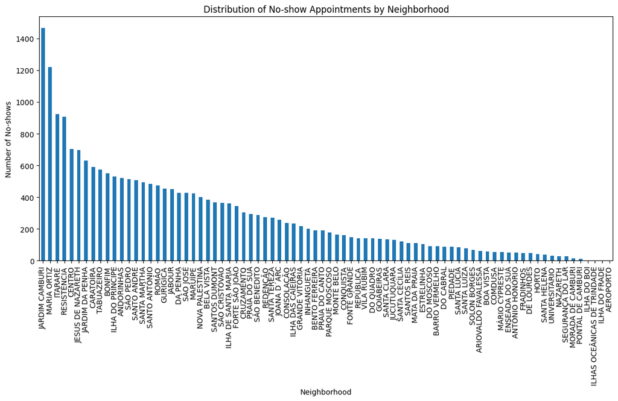

```python
fig, axis = plt.subplots(1, 1, figsize=(14, 6))
neighborhood_no_show = df[df['No-show'] == 'Yes']['Neighbourhood']
plot_no_show_distribution(neighborhood_no_show,
    axis=axis,
    title='Distribution of No-show Appointments by Neighborhood',
    X_label='Neighborhood',
    Y_label='Number of No-shows'
)
plt.show()
```

Let's print the max one name

```python
# Identify the neighborhood with the highest number of no-shows
max_no_show_neighborhood = df[df['No-show'] == 'Yes']['Neighbourhood'].value_counts().idxmax()
print(f"Neighborhood with highest no-show count: {max_no_show_neighborhood}")
```

```
Neighborhood with highest no-show count: JARDIM CAMBURI
```

#### Key Findings

1. Neighborhood with highest no-show count is JARDIM CAMBURI

### Question 2: Which diagnosed conditions are most common among no-show cases?

We need to know plot diagnostic condition class no-show cases vs commitment cases so we can get an idea about their quantities and distribution.

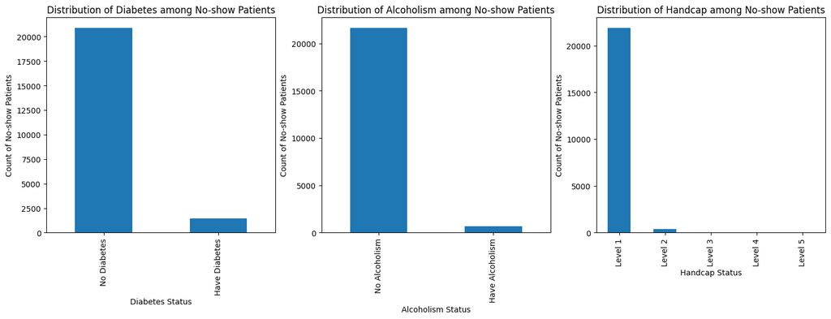

```python
# Visualize diagnostic conditions among no-show patients
fig, axis = plt.subplots(1, 3, figsize=(18, 5))

diabetes_no_show = df[df['No-show'] == 'Yes']['Diabetes']
diabetes_no_show = diabetes_no_show.replace(0, 'No Diabetes').replace(1, 'Have Diabetes')

alcoholism_no_show = df[df['No-show'] == 'Yes']['Alcoholism']
alcoholism_no_show = alcoholism_no_show.replace(0, 'No Alcoholism').replace(1, 'Have Alcoholism')

handcap_no_show = df[df['No-show'] == 'Yes']['Handcap']
handcap_no_show = handcap_no_show.replace(0, 'Level 1').replace(1, 'Level 2').replace(2, 'Level 3').replace(3, 'Level 4').replace(4, 'Level 5')

diabetes_no_show

plot_no_show_distribution(
    diabetes_no_show,
    axis=axis[0],
    X_label='Diabetes Status',
    title='Distribution of Diabetes among No-show Patients',
    Y_label='Count of No-show Patients'
)

plot_no_show_distribution(
    alcoholism_no_show,
    axis=axis[1],
    X_label='Alcoholism Status',
    title='Distribution of Alcoholism among No-show Patients',
    Y_label='Count of No-show Patients'
)

plot_no_show_distribution(
    handcap_no_show,
    axis=axis[2],
    X_label='Handcap Status',
    title='Distribution of Handcap among No-show Patients',
    Y_label='Count of No-show Patients'
)
plt.show()
```

People with conditional diagnosis seem to have less no-show appointments, I think we need to find their over all count

```python
diagnosed_with_conditions = df[(df['Diabetes'] == 1) | (df['Alcoholism'] == 1) | (df['Handcap'] > 0)]
total_diagnosed_with_condition = len(diagnosed_with_conditions)
total_cases = len(df)
```

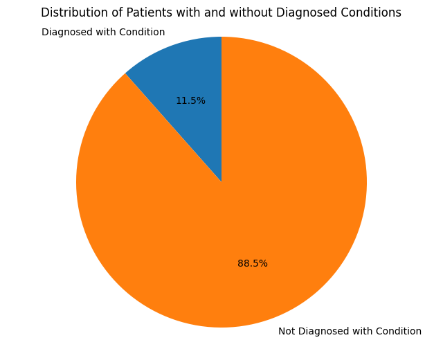

```python
fig, axis = plt.subplots(figsize=(8, 6))
labels = ['Diagnosed with Condition', 'Not Diagnosed with Condition']
counts = [total_diagnosed_with_condition, total_cases - total_diagnosed_with_condition]
axis.pie(counts, labels=labels, autopct='%1.1f%%', startangle=90)
axis.axis('equal')  # Equal aspect ratio ensures that pie is drawn as a circle.
plt.title('Distribution of Patients with and without Diagnosed Conditions')
plt.show()
```

Diagnosed with conditions is 11.5% and not diagnosed with conditions is 88.5% , Let's compare between the no-show and normal records in diagnosed with condition cases

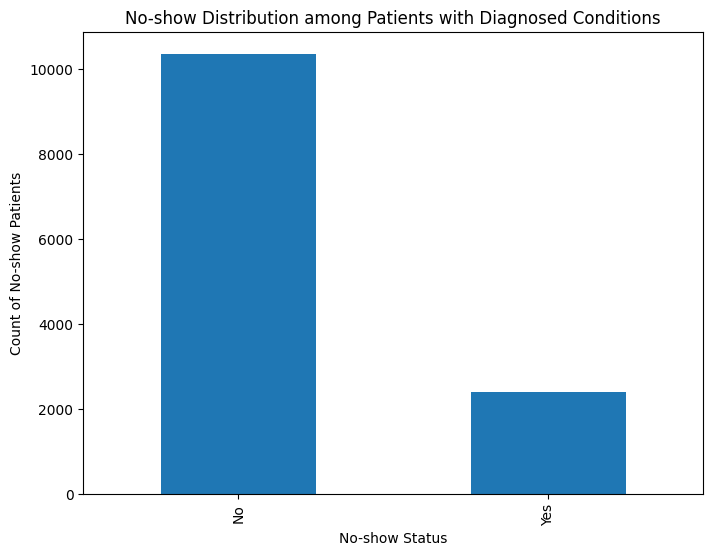

```python
fig, axis = plt.subplots(figsize=(8, 6))
plot_no_show_distribution(
    diagnosed_with_conditions['No-show'],
    axis=axis,
    title='No-show Distribution among Patients with Diagnosed Conditions',
    X_label='No-show Status',
    Y_label='Count of No-show Patients'
)
plt.show()
```

Let's initialize a hypothesis ("Being diagnosed with (Diabetes, Alcoholism, or Handcap) condition will affect no-show rate"), which have a null-hypothesis (Being diagnosed with (Diabetes, Alcoholism, or Handcap) condition will not affect the no-show rate), and test it with chi squared test.

```python
# We'll apply chi-square test to check for association between diagnosed conditions and no-show status
alpha = 0.05
for col in ['Diabetes', 'Alcoholism', 'Handcap']:
    table = pd.crosstab(df[col], df['No-show'])
    chi2, p, _, _ = chi2_contingency(table)
    print(col, "Chi-square statistic:", chi2, "p-value:", p, "Reject null hypothesis:" if p < alpha else "Failed to reject null hypothesis")
```

```
Diabetes Chi-square statistic: 25.322609491076037 p-value: 4.849904575233736e-07 Reject null hypothesis:
Alcoholism Chi-square statistic: 0.0018796207361593989 p-value: 0.9654188731603915 Failed to reject null hypothesis
Handcap Chi-square statistic: 7.03458370865552 p-value: 0.1340718823629825 Failed to reject null hypothesis
```

**Key Findings:**

- Diabetes has the highest no-show count, followed by Alcoholism, then Handcap
- Patients with diagnosed conditions represent only a small portion of total no-shows
- The chi-square test indicates a statistically significant association between Diabetes status and no-show occurrence
- Having Alcoholism or Handcap status is not confirmed to affect your no-show rate

### Question 3: Which gender has the highest number of no-show cases?

Let's have a look at each gender no-show cases count

```python
# Analyze gender distribution among no-show patients
gender_no_show = df[df['No-show'] == 'Yes']['Gender'].value_counts()
print("Gender Distribution among No-show Patients:")
print(gender_no_show)
```

```
Gender Distribution among No-show Patients:
Gender
F    14594
M     7725
Name: count, dtype: int64
```

It looks like females no show cases count are double male's Let's plot each gender no-show cases count

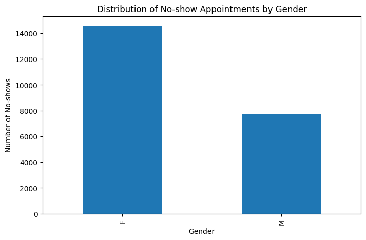

```python
total_no_show_gender = df[df['No-show'] == 'Yes']['Gender']

fig, axis = plt.subplots(1, 1, figsize=(8, 5))
plot_no_show_distribution(
    total_no_show_gender,
    axis=axis,
    title='Distribution of No-show Appointments by Gender',
    X_label='Gender',
    Y_label='Number of No-shows'
)

plt.show()
```

Females have approximately twice the no-show count as males, let's plot the total number of females vs males visits in order to try interpreting this.

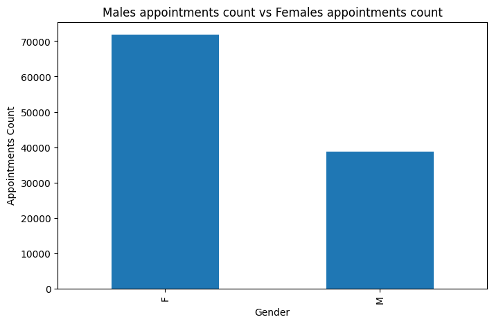

```python
fig, axis = plt.subplots(1, 1, figsize=(8, 5))
plot_no_show_distribution(
    df['Gender'],
    axis=axis,
    title='Males appointments count vs Females appointments count',
    X_label='Gender',
    Y_label='Appointments Count'
)
plt.show()
```

Since females appointments count is twice as big as males this may be the cause of why females no show numbers is double the males.

**Key Findings:**

- Female patients have approximately twice the no-show count as males, and their total appointments count is twice as males which may interpret why their no-show number is males double.

### Question 4: Which weekdays have the highest number of no-show cases?

We need to convert our date form of appointments to week days.

```python
# Analyze no-show distribution across weekdays
df['AppointmentDay'] = pd.to_datetime(df['AppointmentDay'])
df['DayOfWeek'] = df['AppointmentDay'].dt.day_name()
```

Let's have a look each week day no-show cases count and order them

```python
no_show_days = df[df['No-show'] == 'Yes']['DayOfWeek']

print("No-show Distribution by Weekday:")
print(no_show_days.value_counts().sort_values(ascending=False))
```

```
No-show Distribution by Weekday:
DayOfWeek
Tuesday      5152
Wednesday    5093
Monday       4690
Friday       4037
Thursday     3338
Saturday        9
Name: count, dtype: int64
```

It looks like Tuesday have the larger amount of registered no-show cases, let's visualize each day no-show number.

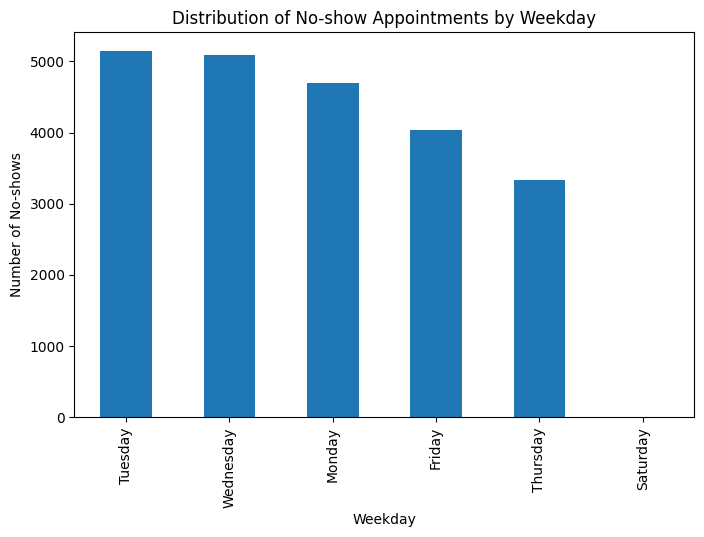

```python
fig, axis = plt.subplots(1, 1, figsize=(8, 5))
plot_no_show_distribution(
    no_show_days,
    axis=axis,
    title='Distribution of No-show Appointments by Weekday',
    X_label='Weekday',
    Y_label='Number of No-shows'
)
plt.show()
```

### Question 5: Does the dataset represent appointment no-shows across the full year?

We need to convert our appointment dats into weeks in the year

```python
# Analyze temporal distribution of no-shows across weeks
df['WeekOfYear'] = df['AppointmentDay'].dt.isocalendar().week
no_show_weeks = df[df['No-show'] == 'Yes'].groupby('WeekOfYear').size()
```

Let's plot each week's total no show cases and see whether we'll have a representive repetitive pattern or not.

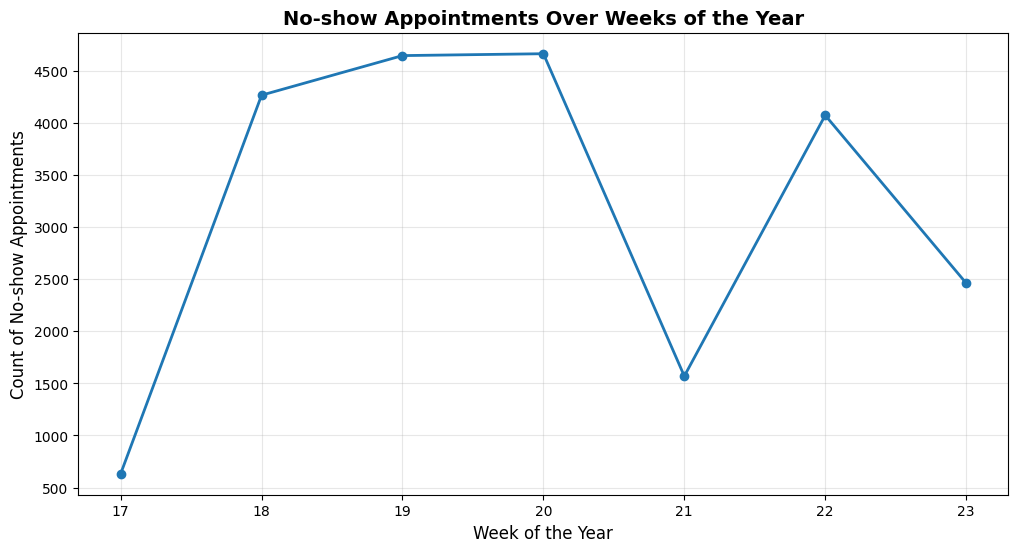

```python
plt.figure(figsize=(12, 6))
plt.plot(no_show_weeks.index, no_show_weeks.values, marker='o', linewidth=2, markersize=6)
plt.title('No-show Appointments Over Weeks of the Year', fontsize=14, fontweight='bold')
plt.xlabel('Week of the Year', fontsize=12)
plt.ylabel('Count of No-show Appointments', fontsize=12)
plt.grid(True, alpha=0.3)
plt.show()
```

**Key Findings:**

- Dataset covers late April through early June only, not a full year
- This limited time frame may not capture seasonal variations

### Question 6: Which age categories have the highest number of no-show cases?

First Let's divide the continuos ages we have into discrete classes

```python
# Create age groups and analyze no-show distribution by age
age_bins = [0, 18, 35, 50, 65, np.inf]
age_labels = ['0-18', '19-35', '36-50', '51-65', '66+']
```

Let's have a look at each Age class total no-show cases

```python
df['AgeGroup'] = pd.cut(df['Age'], bins=age_bins, labels=age_labels)
age_group_no_show = df[df['No-show'] == 'Yes']['AgeGroup'].value_counts().sort_index()

print("Age Group Distribution among No-show Patients:")
print(age_group_no_show)
```

```
Age Group Distribution among No-show Patients:
AgeGroup
0-18     5708
19-35    5753
36-50    4492
51-65    3661
66+      2066
Name: count, dtype: int64
```

It looks like elder people have less total no-show cases , but let's plot each category to it's total no-show cases to grasp distribution better.

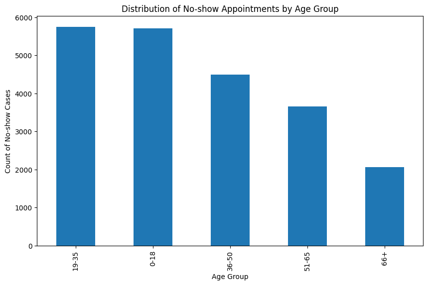

```python
# Visualize age group distribution among no-show patients
fig1, axis1 = plt.subplots(figsize=(10, 6))

plot_no_show_distribution(
    df['AgeGroup'][df['No-show'] == 'Yes'],
    axis=axis1,
    title='Distribution of No-show Appointments by Age Group',
    X_label='Age Group',
    Y_label='Count of No-show Cases'
)
plt.show()
```

**Key Findings:**

- Age group 19–35 has the highest number of no-show cases
- Age groups 66+ have significantly fewer no-show cases

## Question 7: How age values are distributed

We can visualize the distribution of Age using histogram

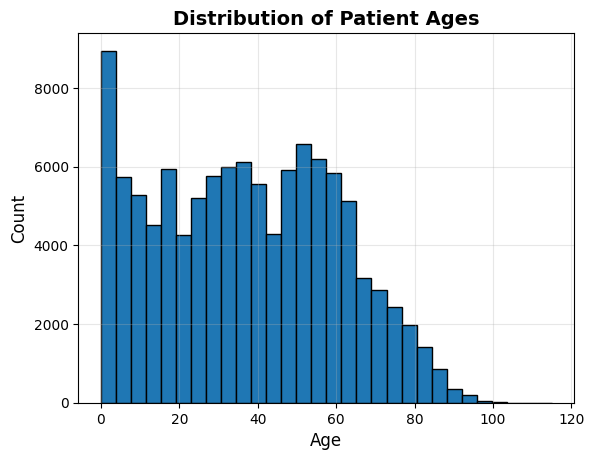

```python
df['Age'].hist(bins=30, edgecolor='black')
plt.title('Distribution of Patient Ages', fontsize=14, fontweight='bold')
plt.xlabel('Age', fontsize=12)
plt.ylabel('Count', fontsize=12)
plt.grid(True, alpha=0.3)
plt.show()
```

Let's print the skewness of age variable so we can decide if we will consider it as normally distributed or skewed.

```python
print(df['Age'].skew())
```

```
0.12165837918663781
```

## Question 8: How females Age distribution differ from males

We can visualize a histogram female and male ages distribution and compare them

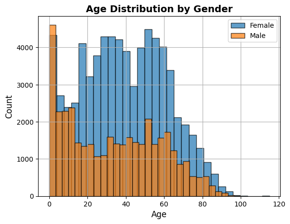

```python
df[df["Gender"] == 'F']['Age'].hist(bins=30, edgecolor='black', alpha=0.7, label='Female')
df[df["Gender"] == 'M']['Age'].hist(bins=30, edgecolor='black', alpha=0.7, label='Male')
plt.title('Age Distribution by Gender', fontsize=14, fontweight='bold')
plt.xlabel('Age', fontsize=12)
plt.ylabel('Count', fontsize=12)
plt.legend()
plt.show()
```

We need to test the skewness of each male's and females to know if we will classift them as normal distribution or skewed distribution

```python
print(f"Female skewness: {df[df['Gender'] == 'F']['Age'].skew()}")
print(f"Male skewness: {df[df['Gender'] == 'M']['Age'].skew()}")
```

```
Female skewness: 0.08634326143817411
Male skewness: 0.24960948181291678
```

#### Key Findings

1. The age distribution appears approximately symmetric with low skewness.
2. The dataset includes patients across multiple age categories for both genders, indicating broad age coverage. However, representativeness cannot be fully confirmed without knowledge of the sampling process or comparison with population demographics.

## Limitations

### Recommendations for Future Work

- Collect data across multiple years to identify seasonal and long-term trends
- Incorporate additional variables such as appointment reminder type, lead time before appointment, and socioeconomic indicators
- Apply predictive modeling to identify high-risk no-show cases and develop targeted interventions
- Conduct sensitivity analysis across different geographic regions to validate generalizability